# Homework 2 (CSC 495)

Brian Craft

Spring 2017

## Working with the Beer Advocate data

### Bipartite networks and ego networks

```r
library(knitr)
setwd("~/Documents/Craft-Repo/social_networks/homework_2")

read_chunk("hwk2.R")
knitr::opts_chunk$set(echo = TRUE)
```

### Step 1: Load libraries

```r
# Load libraries

library("ggplot2")
# Must load other packages first before SAND
library("sand")
library("intergraph")
```

### Step 2: Load the data *1 pt*

Load a bipartite network built from the “Beer Advocate” review data. For the purposes of this assignment, I selected only very active users (> 1000 reviews), chose the beers with the very top ratings (> 4.5 out of 5) and looked at just “American IPA” style beers. This gives a network of managable size with 278 nodes (131 beers and 147 users).

The data is in edgelist and attribute form, so we have to shape it into a network first. The two files are

- beer_edges.csv
- beer_attrs.csv

```r
# Load edge and attribute data
setwd("~/Documents/Craft-Repo/social_networks/homework_2")
beer.edges = read.csv("beer_edges.csv", stringsAsFactors = FALSE)
beer.nodes = read.csv("beer_attrs.csv", stringsAsFactors = FALSE)
head(beer.edges)
```

```
##        user beer_id
## 1 aerozeppl    6368
## 2 aerozeppl   17443
## 3 aerozeppl   22790
## 4 aerozeppl   22790
## 5 aerozeppl   29619
## 6 aerozeppl   30420
```

```r
head(beer.nodes)
```

```
##   beer_id                     brewery
## 1   33624        Hoppin' Frog Brewery
## 2    4373 Harmon Restaurant & Brewery
## 3    5441    Founders Brewing Company
## 4     505   Cambridge Brewing Company
## 5   20478    Founders Brewing Company
## 6   37477   Sierra Nevada Brewing Co.
##                                   beer.name alcohol type
## 1                     Hoppin' To Heaven IPA     6.8 TRUE
## 2                        Point Defiance IPA     6.1 TRUE
## 3                   Founders Centennial IPA     7.2 TRUE
## 4                               Big Man Ale     6.8 TRUE
## 5                      Founders Harvest Ale     6.5 TRUE
## 6 Sierra Nevada Anniversary Ale (2007-2009)     5.9 TRUE
```

### Step 3: Use graph.data.frame to convert to graph *1 pt*

```r
# Convert to graph
graph = graph.data.frame(beer.edges, vertices = beer.nodes, directed = FALSE)
summary(graph)
```

```
## IGRAPH UN-B 278 962 --
## + attr: name (v/c), brewery (v/c), beer.name (v/c), alcohol (v/n),
## | type (v/l)
```

### Step 4: Looking at attributes *1 pt*

List the vertex attributes and note that most attributes are for beers. We don’t have attributes for users.

Use the `head` function to list the first 6 (head) beer names (not the numeric IDs)

```r
# Examine attributes
head(V(graph)$beer.name)
```

```
## [1] "Hoppin' To Heaven IPA"
## [2] "Point Defiance IPA"
## [3] "Founders Centennial IPA"
## [4] "Big Man Ale"
## [5] "Founders Harvest Ale"
## [6] "Sierra Nevada Anniversary Ale (2007-2009)"
```

### Step 5: Projection *1 pt*

Compute the user-user and beer-beer projections and print the `summary` information for each.

```r
# Projections
V(graph)$beer.name[1:5]
```

```
## [1] "Hoppin' To Heaven IPA"   "Point Defiance IPA"
## [3] "Founders Centennial IPA" "Big Man Ale"
## [5] "Founders Harvest Ale"
```

```r
V(graph)$type[1:5] # the beers are true
```

```
## [1] TRUE TRUE TRUE TRUE TRUE
```

```r
b2b.beer = bipartite.projection(graph, which = "true")
u2u.beer = bipartite.projection(graph, which = "false")
summary(b2b.beer) # 131 beers
```

```
## IGRAPH UNW- 131 2373 --
## + attr: name (v/c), brewery (v/c), beer.name (v/c), alcohol (v/n),
## | weight (e/n)
```

```r
summary(u2u.beer) # 147 users
```

```
## IGRAPH UNW- 147 5070 --
## + attr: name (v/c), brewery (v/c), beer.name (v/c), alcohol (v/n),
## | weight (e/n)
```

### Step 6: Fixing the attributes *1 pt*

Remove the irrelevant attributes from the user-user network. Print the summary at the end. It should show only “name” and “weight” attributes. Use `delete_vertex_attr`.

```r
# Remove non-user attributes
u2u.beer = remove.vertex.attribute(u2u.beer, "beer.name")
u2u.beer = remove.vertex.attribute(u2u.beer, "brewery")
u2u.beer = remove.vertex.attribute(u2u.beer, "alcohol")
summary(u2u.beer)
```

```
## IGRAPH UNW- 147 5070 --
## + attr: name (v/c), weight (e/n)
```

### Step 7: Plot the edge weight distribution *2 pt*

You can use either base plotting or ggplot. Label your plots appropriately (x and y axes, main title). Make sure that the whole distribution is included – set x axis limits correctly.

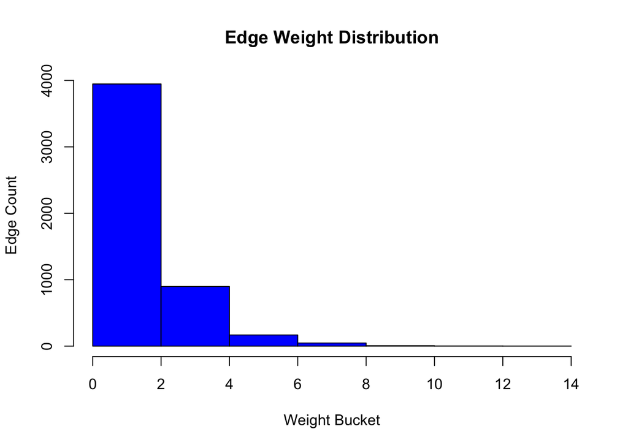

```r
# Edge weight histogram
hist(E(u2u.beer)$weight, xlab = "Weight Bucket", ylab = "Edge Count",
     main = "Edge Weight Distribution", breaks = 5, col = "Blue")
```

### Step 8: Filter out edges of weight < 6 *2 pts*

As is typical with projections of bipartite networks, we’ll filter out the low weight edges of which there are very many.

```r
# Filter edges of weight less than 6
u2u.beer.filt = delete.edges(u2u.beer, E(u2u.beer)[E(u2u.beer)$weight < 6])
summary(u2u.beer.filt)
```

```
## IGRAPH UNW- 147 109 --
## + attr: name (v/c), weight (e/n)
```

### Step 9: Remove singletons (nodes of degree == 0) *1 pt*

Removing edges leaves some nodes disconnected from the network so we remove them also. Another way to do this would be calculate the largest (giant) component.

```r
# Remove singleton nodes
V(u2u.beer.filt)[degree(u2u.beer.filt) == 0]
```

```
## + 102/147 vertices, named:
##   [1] allergictomacros alleykatking     Arbitrator       argock
##   [5] avalon07         barleywinefiend  Beerandraiderfan BEERchitect
##   [9] BeerSox          biegaman         Bierman9         billab914
##  [13] blitheringidiot  bobsy            Brad007          brentk56
##  [17] canucklehead     ClockworkOrange  cokes            cpetrone84
##  [21] CrellMoset       crossovert       Cyberkedi        Derek
##  [25] DogFood11        DoubleJ          drabmuh          DrJay
##  [29] drpimento        feloniousmonk    flexabull        Floydster
##  [33] francisweizen    Frozensoul327    garymuchow       GCBrewingCo
##  [37] GClarkage        Georgiabeer      gford217         glid02
## + ... omitted several vertices
```

```r
u2u.beer.filt = delete.vertices(u2u.beer.filt, V(u2u.beer.filt)[degree(u2u.beer.filt) == 0])
summary(u2u.beer.filt)
```

```
## IGRAPH UNW- 45 109 --
## + attr: name (v/c), weight (e/n)
```

### Note: *Use the filtered version of the network for the rest of the assignment.*

### Step 10: Plot the network *1 pt*

The graph is now simplified enough that it can be visualized. Use the Kamada-Kawai layout: `layout=layout_with_kk`.

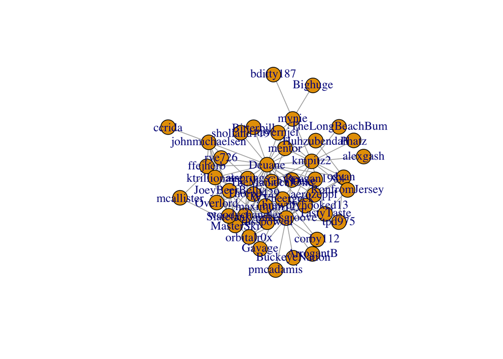

```r
# Plot
lo = layout_with_kk(u2u.beer.filt)
plot(u2u.beer.filt, layout = lo)
```

### Step 11: Weighted degree *2 pt*

Compute a histogram of the weighted degree. (`graph.strength` function)

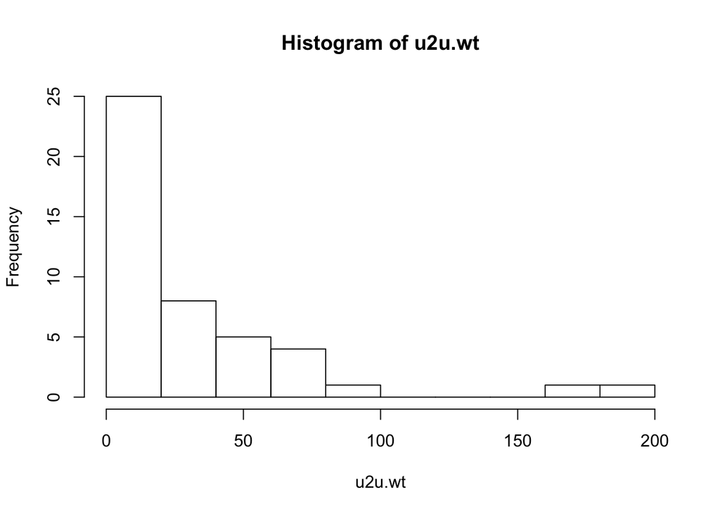

```r
# Weighted degree histogram
wt = E(u2u.beer.filt)$weight
u2u.wt = graph.strength(u2u.beer.filt, vids = V(u2u.beer.filt), mode = "all", weights = wt, loops = FALSE)
hist(u2u.wt)
```

### Step 12: Find outliers *2 pt*

Find the names of the two individuals with highest weighted degree (2 outliers)

```r
# Find 2 highest weighted degree individuals
V(u2u.beer.filt)[u2u.wt > 150]
```

```
## + 2/45 vertices, named:
## [1] Deuane      mikesgroove
```

### Step 13: Compute the ego networks *1 pt*

Compute the ego networks for these two users.

```r
# Create ego networks
which(V(u2u.beer.filt)$name == "Deuane") # 12
```

```
## [1] 12
```

```r
which(V(u2u.beer.filt)$name == "mikesgroove") # 26
```

```
## [1] 26
```

```r
egos = make_ego_graph(u2u.beer.filt, 1, c(12,26))
deuane = egos[[1]]
mikesgroove = egos[[2]]
```

### Step 14: Plot the ego networks side by side *1 pt*

Use par(mfrow=c(1,2)) to get the side-by-side layout. Remember to switch back to the normal layout c(1,1) after.

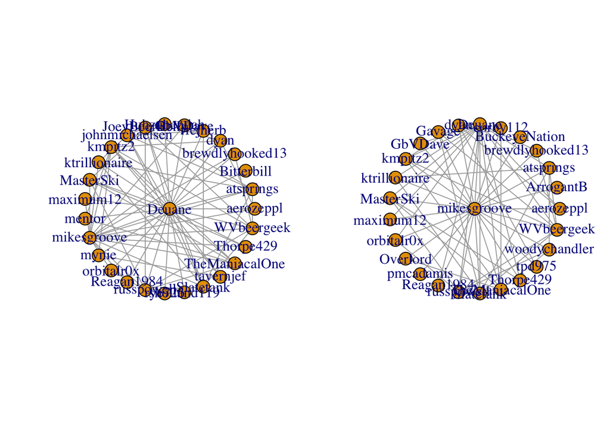

```r
# Plot ego networks
lo_deuane = layout_as_star(deuane, V(deuane)[5])
lo_mikesgroove = layout_as_star(mikesgroove, V(mikesgroove)[15])
par(mfrow = c(1,2))
plot(deuane, layout = lo_deuane)
plot(mikesgroove, layout = lo_mikesgroove)
```

```r
par(mfrow = c(1,1))
```

### Step 15: Question *3 pts*

In reducing the size of the network through edge and vertex filtering (steps 8 and 9) so that it is easier to visualize, what information about the original user-user network has been lost? What consequences does this have for our interpretation of the filtered version of the network?

It’s possible that by removing weights less than 6 many singeltons were created, which was step 8. Then in step 9, we remove the singeltons, which may have been because of step 8. In conjunction, we lost a lot of information about less active users, since they are not rating as many items, which could mean selectivity. For instance, perhaps many of those individuals rated the same selective number of beers because they are from the same area. Essentially, we lose information on how the less engaged users are connected.